# PROJET FINAL STATISTIQUES POUR LA GÉNÉTIQUE 2019-2020

UNIVERSITÉ DE PARIS / MASTER 1 INGÉNIERIE MATHÉMATIQUE ET BIOSTATISTIQUE

James Kelson LOUIS

4/30/2020

#### On se pose le problème d’identifier le modèle sous-jacent à une maladie donnée par analyse de ségrégation. Pour cela on considère le pedigree de la figure dans lequel les individus en gris sont atteints par la maladie. On note $\mathbf{G_{i}}$ le génotype de l’individu i et $\mathbf{P_{i}}$ son phénotype (1 pour malade et 0 pour sain).

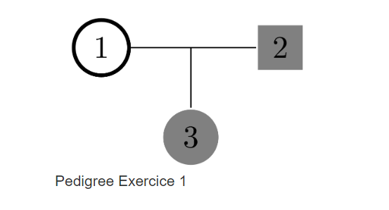

#### On fait l’hypothèse que la maladie est une maladie génétique due à mutation dans un seul locus d’allèles S,s. On suppose que la fréquence de l’allèle de susceptibilité $S$ est $q$ et que il y a équilibre de Hardy-Weinberg.

#### On commence par considérer un modèle de maladie dominant à pénétrance complète.

#### 1. Écrivons les fonctions de pénétrance $\mathbf{P(\mathit{P}=1|\mathit{G}=g)}$ pour tous les trois génotypes possibles.

##### a) $\mathbf{P(\mathit{P}=1|\mathit{G}=SS)}=1$

##### b) $\mathbf{P(\mathit{P}=1|\mathit{G}=Ss)}=1$

##### c) $\mathbf{P(\mathit{P}=1|\mathit{G}=ss)}=0$

#### 2. Trouvons les génotypes possibles pour chaque individu.

#### Il s’agit d’un modèle de maladie dominant à pénétrance complète, et d’après le pedigree l’individu 1 n’est pas malade et les autres sont malades, forcémment $\mathbf{G_{1}=ss}$.

#### Pour l’individu 2 on peut considérer deux cas.

$\begin{array}{l|cr} G2|G1 & ss &\\ \hline Ss & Ss & ss\\& &\\\hline SS &Ss&\\\end{array}$

#### a) Si $\mathbf{G_{2}=Ss}$, alors $\mathbf{G_{3}=Ss}$ ou $\mathbf{G_{3}=ss}$, par contre on ne peut pas avoir $\mathbf{G_{3}=ss}$ pour le modèle considéré car l’individu 3 est malade.

#### b) Si $\mathbf{G_{2}=SS}$ alors $\mathbf{G_{3}=Ss}$.

#### Au final les génotypes possibles sont: $\mathbf{G_{1}=ss}$, $\mathbf{G_{2}=Ss}$ ou $\mathbf{G_{2}=SS}$ et $\mathbf{G_{3}=Ss}$.

#### 3. Pour tout génotype possible $\mathit{g_{1}}$ pour l’individu 1, calculons $\mathbf{P(\mathit{G_{1}}=\mathit{g_{1}})}$.

#### Pour l’individu 1 $\mathit{g_{1}}=ss$ Sous l’hypothèse Hardy-Weinberg

$\mathbf{P(\mathit{G_{1}}=ss)}=(1-q)^{2}$.

#### Pour l’individu 2 :

#### Si $\mathit{g_{2}}=Ss$, sous l’hypothèse Hardy-Weinberg

$\mathbf{P(\mathit{G_{2}}=Ss)}=2\times q\times(1-q)$.

#### Si $\mathit{g_{2}}=SS$, sous l’hypothèse Hardy-Weinberg

$\mathbf{P(\mathit{G_{2}}=SS)}=q^{2}$.

#### 4. Pour chaque combinaison de génotypes possibles $(\mathit{g_{1}},\mathit{g_{2}},\mathit{g_{3}})$, calculons $\mathbf{P(\mathit{G_{3}}=\mathit{g_{3}}|\mathit{G_{1}}=\mathit{g_{1}},\mathit{G_{2}}=\mathit{g_{2}})}$

$\mathbf{P(\mathit{G_{3}}=Ss|\mathit{G_{1}}=ss,\mathit{G_{2}}=Ss)}=\frac{1}{2}$

$\mathbf{P(\mathit{G_{3}}=Ss|\mathit{G_{1}}=ss,\mathit{G_{2}}=SS)}=1$.

#### 5. Écrivons la vraissemblance du trio sous ce modèle de maladie, à l’aide des questions précédentes.

$\mathbf{V_{1}}=\mathbf{P(\mathit{P_{1}}=0|\mathit{P_{2}}=1,\mathit{P_{3}}=1)}$ Pour calculer cette probabilité, on utilise la règle de la chaine.

$V=\mathbf{P(\mathit{P_{1}=0})}\times \mathbf{P(\mathit{P_{2}}=1|\mathit{P_{1}}=0)\times \mathbf{P(\mathit{P_{3}}=1|\mathit{P_{1}}=0,\mathit{P_{2}}=1)}}$

** $\mathbf{P(\mathit{P_{1}=0})}=\mathbf{P(\mathit{P_{1}=0}|\mathit{G}=SS)}\times \mathbf{P(\mathit{G=SS})}+\mathbf{P(\mathit{P_{1}=0}|\mathit{G}=Ss)}\times \mathbf{P(\mathit{G=Ss})}+\mathbf{P(\mathit{P_{1}=0}|\mathit{G}=ss)}\times \mathbf{P(\mathit{G=ss})}$

** $\mathbf{P(\mathit{P_{1}=0})}=0\times 1+0\times 2 q (1-q)+1\times (1-q)^{2}=(1-q)^{2}$

** $\mathit{P_{2}} \bot \mathit{P_{1}}$

** $\mathbf{P(\mathit{P_{2}}=1|\mathit{P_{1}}=0)}=\mathbf{P(\mathit{P_{2}}=1)}$

** $\mathbf{P(\mathit{P_{2}=1})}=\mathbf{P(\mathit{P_{2}=1}|\mathit{G}=SS)}\times \mathbf{P(\mathit{G=SS})}+\mathbf{P(\mathit{P_{2}=1}|\mathit{G}=Ss)}\times \mathbf{P(\mathit{G=Ss})}+\mathbf{P(\mathit{P_{2}=1}|\mathit{G}=ss)}\times \mathbf{P(\mathit{G=ss})}$

** $\mathbf{P(\mathit{P_{2}=1})}=1\times q^{2}+1\times 2q (1-q)+0\times(1-q)^{2}=q^{2}+2q(1-q)=q(2-q)$

** $\mathbf{P(\mathit{P_{3}=1}|\mathit{P_{1}=0},\mathit{P_{2}=1})}=\mathbf{P(\mathit{P_{3}=1}|\mathit{G_{3}=Ss})}\times \mathbf{P(\mathit{G_{3}=Ss}|\mathit{G_{1}=ss},\mathit{G_{2}=SS})}+\mathbf{P(\mathit{P_{3}=1}|\mathit{G_{3}=Ss})}\times\mathbf{P(\mathit{G_{3}=Ss}|\mathit{G_{1}=ss},\mathit{G_{2}=Ss})}$

** $\mathbf{P(\mathit{P_{3}=1}|\mathit{P_{1}=0},\mathit{P_{2}=1})}=1\times 1+ 1\times \frac{1}{2}=\frac{3}{2}$

#### Il vient alors:

$\mathbf{V_{1}}=(1-q)^{2}\times q(2-q)\times \frac{3}{2}$

#### 6. Calculons la vraissemblance du trio si $q=\frac{1}{2}$

#### Pour $q=\frac{1}{2}$

#### $\mathbf{V_{1}}=\frac{9}{32}$

#### ou $\boxed{\mathbf{V_{1}}=0.28125}$

#### Pour l’instant on va considérer un modèle de maladie récessif à pénétrance complète.

#### Les fonctions de pénétrances pour ce modèle sont:

##### a) $\mathbf{P(\mathit{P}=1|\mathit{G}=SS)}=1$

##### b) $\mathbf{P(\mathit{P}=1|\mathit{G}=Ss)}=0$

##### c) $\mathbf{P(\mathit{P}=1|\mathit{G}=ss)}=0$

#### Trouvons les génotypes possibles pour ce modèle

#### L’individu 1 n’est pas malade, son génotype est soit $\mathbf{G_{1}=ss}$ soit $\mathbf{G_{1}=Ss}$. L’individu 2 est malade, forcément son génotype est $\mathbf{G_{2}=SS}$, pareil pour l’individu 3, $\mathbf{G_{3}=SS}$.

$\begin{array}{l|cr} G1|G2 & SS & \\ \hline ss & Ss & \\ Ss & SS & Ss\\\hline &&\\\end{array}$

#### $1^{er}$ cas, si $\mathbf{G_{1}=ss}$ et $\mathbf{G_{2}=SS}$, alors $\mathbf{G_{3}=Ss}$ ce qui est impossible pour le modèle considéré, car l’individu 3 est malade.

#### $2^{ème}$ cas, si $\mathbf{G_{1}=Ss}$ et $\mathbf{G_{2}=SS}$, alors soit $\mathbf{G_{3}=SS}$ soit $\mathbf{G_{3}=Ss}$, le même raisonnement montre que ce dernier cas $\mathbf{G_{3}=Ss}$ n’est pas possible.

#### Les génotypes possibles sont: $\mathbf{G_{1}=Ss}$, $\mathbf{G_{2}=SS}$ et $\mathbf{G_{3}=SS}$

#### Calculons la vraissemblance de ce trio pour ce modèle.

$\mathbf{V_{2}}=\mathbf{P(\mathit{P_{1}}=0|\mathit{P_{2}}=1,\mathit{P_{3}}=1)}$

$\mathbf{V_{2}}=\mathbf{P(\mathit{P_{1}=0})}\times \mathbf{P(\mathit{P_{2}}=1|\mathit{P_{1}}=0)\times \mathbf{P(\mathit{P_{3}}=1|\mathit{P_{1}}=0,\mathit{P_{2}}=1)}}$

** $\mathbf{P(\mathit{P_{1}=0})}=\mathbf{P(\mathit{P_{1}=0}|\mathit{G}=SS)}\times \mathbf{P(\mathit{G=SS})}+\mathbf{P(\mathit{P_{1}=0}|\mathit{G}=Ss)}\times \mathbf{P(\mathit{G=Ss})}+\mathbf{P(\mathit{P_{1}=0}|\mathit{G}=ss)}\times \mathbf{P(\mathit{G=ss})}$

** $\mathbf{P(\mathit{P_{1}=0})}=0\times q^{2}+1\times 2q(1-q)+1\times (1-q)^{2}=1-q^{2}$

** $\mathbf{P(\mathit{P_{2}=1}|\mathit{P_{1}=0})}=\mathbf{P(\mathit{P_{2}}=1)}$

** $\mathbf{P(\mathit{P_{2}=1})}=\mathbf{P(\mathit{P_{2}=1}|\mathit{G}=SS)}\times \mathbf{P(\mathit{G=SS})}+\mathbf{P(\mathit{P_{2}=1}|\mathit{G}=Ss)}\times \mathbf{P(\mathit{G=Ss})}+\mathbf{P(\mathit{P_{2}=1}|\mathit{G}=ss)}\times \mathbf{P(\mathit{G=ss})}$

** $\mathbf{P(\mathit{P_{2}=1})}=1\times q^{2}+0\times2q(1-q)+0\times (1-q)^{2}=q^{2}$

** $\mathbf{P(\mathit{P_{3}=1}|\mathit{P_{1}=0},\mathit{P_{2}=1})}=\mathbf{P(\mathit{P_{3}=1}|\mathit{G_{3}=SS})}\times \mathbf{P(\mathit{G_{3}=SS}|\mathit{G_{1}=Ss},\mathit{G_{2}=SS})}$

** $\mathbf{P(\mathit{P_{3}=1}|\mathit{P_{1}=0},\mathit{P_{2}=1})}= 1\times \frac{1}{2}=\frac{1}{2}$

#### La vraissemblance s’écrit:

#### $\mathbf{V_{2}}=(1-q^{2})\times q^{2}\times \frac{1}{2}$

#### $\mathbf{V_{2}}=(1-{(\frac{1}{2})}^{2})\times {(\frac{1}{2})}^{2}\times \frac{1}{2}$

#### Soit $\mathbf{V_{2}}=\frac{3}{32}$

#### ou $\boxed{\mathbf{V_{2}}=0.09375}$

#### Enfin, on suppose que la maladie n’a pas de composante génétique. On note $\mathit{F}$ la fréquence de la maladie dans la population.

#### 8. Écrivons la vraissemblance du trio observé sous cette nouvelle hypothèse.

$\mathbf{V_{3}}=(1-F)\times {F}^{2}$

#### 9. Calculons la vraissemblance du trio sous cette nouvelle hypothèse, si $\mathit{F}=\frac{1}{20}$.

$\mathbf{V_{3}}=(1-\frac{1}{20}) \times {(\frac{1}{20})}^{2}$

$\mathbf{V_{3}}=\frac{19}{20} \times {(\frac{1}{400})}$

$\mathbf{V_{3}}=\frac{19}{8000}$

$\boxed {\mathbf{V_{3}}=0.002375}$

#### 10. Au vu du trio observé, nous avons $\mathbf{V_{3}}<\mathbf{V_{2}}<\mathbf{V_{1}}$, donc le modèle de maladie le plus probable est le modèle 1.

```r
hgdp<- read.delim("C:/Users/james/OneDrive/Desktop/DocParisDescartes/S2/StatGen2/HGDP_AKT1.txt", header=1)
```

```r
attach(hgdp)
```

```r
nrow(hgdp)
```

```
## [1] 1064
```

```r
SNP_AKT1 <- names(hgdp)[startsWith(names(hgdp),"AKT1")]
length(SNP_AKT1)
```

```
## [1] 4
```

```r
table(Gender)
```

```
## Gender
##   F   M
## 380 684
```

#### Soit 380 Femmes et 684 Hommes.

```r
length(levels(Population))
```

```
## [1] 52
```

```r
length(unique(Geographic.area))
```

```
## [1] 14
```

```r
length(summary(Geographic.area))
```

```
## [1] 14
```

```r
Plus <- rev(tail(as.factor(sort(summary(Population))),4))
Plus1 <- as.numeric(rev(levels(Plus)))[1:4]
names(Plus1) <- attributes(Plus)$names
Plus1
```

```
## Palestinian     Bedouin       Druze         Han
##          51          49          48          45
```

```r
Moins <- (head(as.factor(sort(summary(Population))),4))
Moins1 <- as.numeric(levels(Moins))[1:4]
names(Moins1) <- attributes(Moins)$names
Moins1
```

```
##   San  Tuscan   Xibo    Dai
##      7      8      9     10
```

```r
plus <- rev(tail(as.factor(sort(summary(Geographic.area))),4))
plus1 <- as.numeric(rev(levels(plus)))[1:4]
names(plus1) <- attributes(plus)$names
plus1
```

```
##        Pakistan           China          Israel Southern Europe
##             200             184             148             125
```

```r
moins <- (head(as.factor(sort(summary(Geographic.area))),4))
moins1 <- as.numeric(levels(moins))[1:4]
names(moins1) <- attributes(moins)$names
moins1
```

```
##    South Africa  Southeast Asia Northern Europe      New Guinea
##               8              11              16              17
```

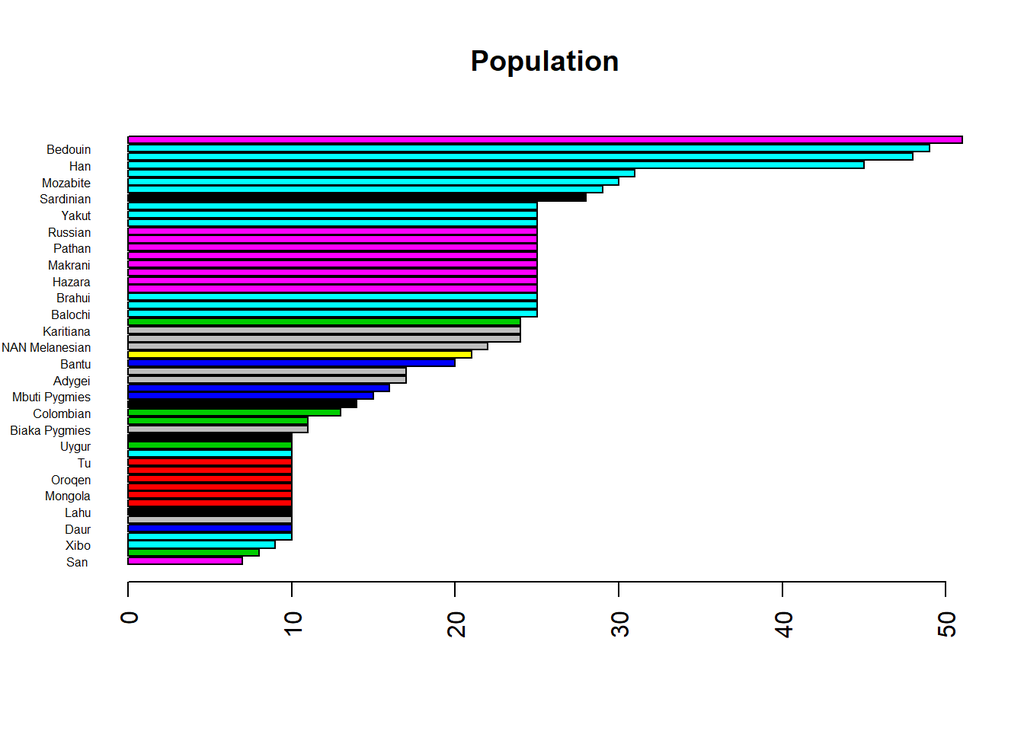

```r
barplot(sort(table(Population)),horiz=TRUE,las=2,cex.names=0.5, col = Population,main=" Population")
```

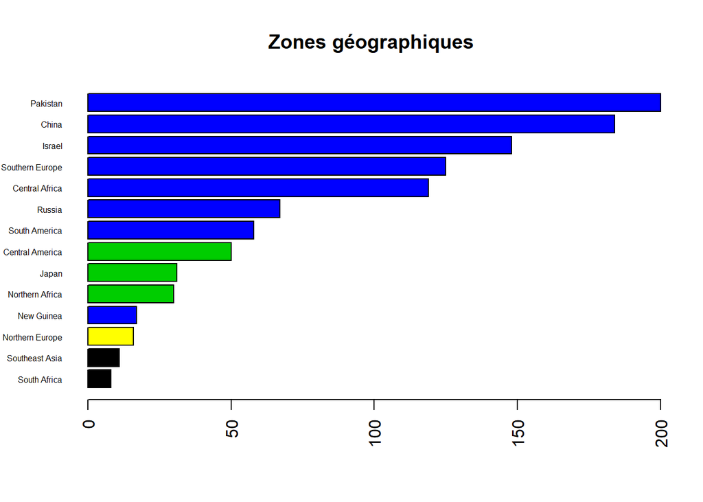

```r
barplot(sort(table(Geographic.area)),horiz=TRUE,las=2,cex.names=0.5, col = Geographic.area, main="Zones géographiques")
```

```r
geno1 <- genotype(AKT1.C6024T, sep="")
```

```r
summary(geno1)
```

```
##
## Number of samples typed: 1063 (99.9%)
##
## Allele Frequency: (2 alleles)
##    Count Proportion
## C   1732       0.81
## T    394       0.19
## NA     2         NA
##
##
## Genotype Frequency:
##     Count Proportion
## C/C   719       0.68
## C/T   294       0.28
## T/T    50       0.05
## NA      1         NA
##
## Heterozygosity (Hu)  = 0.3021008
## Poly. Inf. Content   = 0.2563692
```

```r
(gen <- table(Geographic.area, AKT1.C6024T))
```

```
##                  AKT1.C6024T
## Geographic.area    CC  CT  TT
##   Central Africa   55  50  14
##   Central America  39  10   1
##   China           142  39   3
##   Israel          106  36   6
##   Japan            19  12   0
##   New Guinea       16   1   0
##   Northern Africa  17  11   2
##   Northern Europe   9   7   0
##   Pakistan        140  52   8
##   Russia           47  15   5
##   South Africa      5   3   0
##   South America    46   5   7
##   Southeast Asia    9   1   0
##   Southern Europe  69  52   4
```

#### Proportions

```r
(prop_gen <- prop.table(gen,1)*100)
```

```
##                  AKT1.C6024T
## Geographic.area          CC        CT        TT
##   Central Africa  46.218487 42.016807 11.764706
##   Central America 78.000000 20.000000  2.000000
##   China           77.173913 21.195652  1.630435
##   Israel          71.621622 24.324324  4.054054
##   Japan           61.290323 38.709677  0.000000
##   New Guinea      94.117647  5.882353  0.000000
##   Northern Africa 56.666667 36.666667  6.666667
##   Northern Europe 56.250000 43.750000  0.000000
##   Pakistan        70.000000 26.000000  4.000000
##   Russia          70.149254 22.388060  7.462687
##   South Africa    62.500000 37.500000  0.000000
##   South America   79.310345  8.620690 12.068966
##   Southeast Asia  90.000000 10.000000  0.000000
##   Southern Europe 55.200000 41.600000  3.200000
```

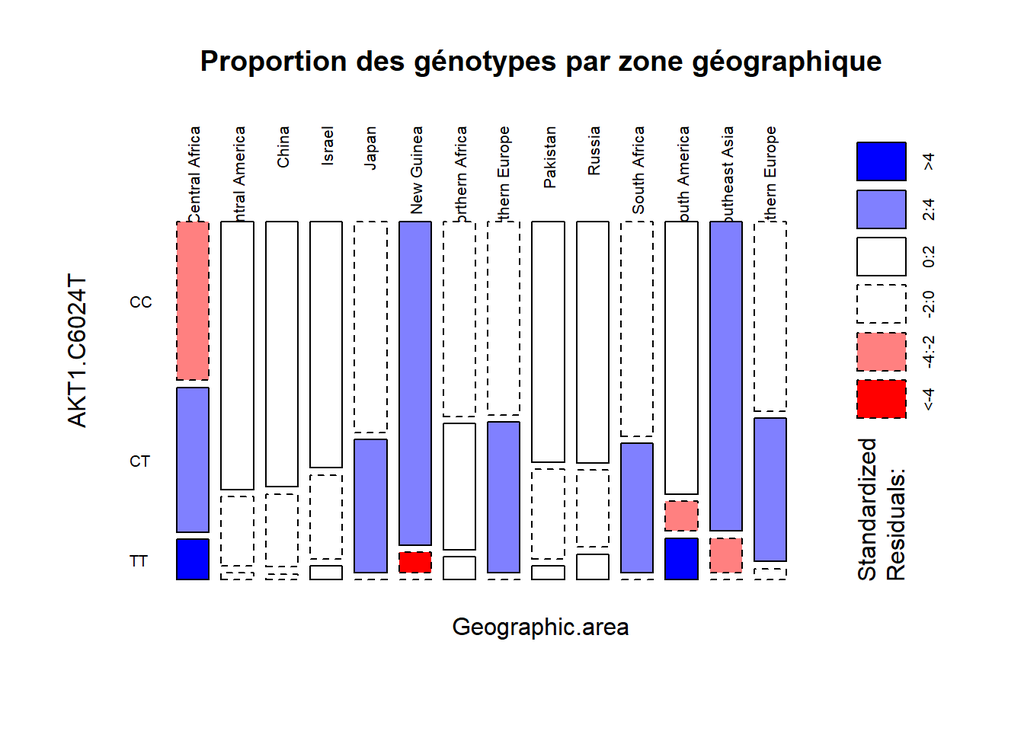

```r
library("graphics")
mosaicplot(prop_gen, shade = TRUE, las=2,
           main = "Proportion des génotypes par zone géographique")
```

```r
chisq.test(prop_gen)
```

```
##
##  Pearson's Chi-squared test
##
## data:  prop_gen
## X-squared = 180.57, df = 26, p-value < 2.2e-16
```

#### Au vu de la p-valeur, on peut conclure que les proportions des génotypes par zones géographiques sont statistiquement liées.

```r
snp_names <- names(hgdp)[substr(names(hgdp),start=1,stop=5)=='AKT1.']
snps <- hgdp[snp_names]
for (i in 1:length(snp_names)) snps[,i]<-genotype(snps[,i],sep='')
LD(snps)$"D'"
```

```
##             AKT1.C0756A AKT1.C6024T AKT1.G2347T AKT1.G2375A
## AKT1.C0756A          NA   0.9934369   0.9481195   0.9843420
## AKT1.C6024T          NA          NA   0.9429031   0.9842787
## AKT1.G2347T          NA          NA          NA   0.9995238
## AKT1.G2375A          NA          NA          NA          NA
```

#### Au vu des résultats, on constate que la mesure D’ de déséquilibre de liaison entre les paires de SNPs dans le gène AKT1 est toujours très proche de 1, on conclut qu’il y a un fort déséquilibre de liaison entre eux.

```r
 fms <- read.delim("C:/Users/james/OneDrive/Desktop/DocParisDescartes/S2/StatGen2/FMS_data.txt", header=1,fill = 1)
```

```r
table(fms$Race)
```

```
##
## African Am  Am Indian      Asian  Caucasian   Hispanic      Other
##         44          1         97        791         52         49
```

```r
which(fms$Race=="Am Indian")
```

```
## [1] 1107
```

```r
fms <- fms[-1107,]
```

```r
table(fms$Race)
```

```
##
## African Am  Am Indian      Asian  Caucasian   Hispanic      Other
##         44          0         97        791         52         49
```

#### Testons si le SNP akt1_t10726c_t12868c est en HWE dans l’ensemble de la population

```r
geno2 <- genotype(fms$akt1_t10726c_t12868c,sep='')
summary(fms$akt1_t10726c_t12868c)
```

```
##   CC   TC   TT NA's
##  881  301   62  152
```

```r
n=sum(table(geno2))
GenoCount <- table(geno2)
(GenoFreq <- GenoCount/n)
```

```
## geno2
##        C/C        C/T        T/T
## 0.70819936 0.24196141 0.04983923
```

```r
FreqC <- setNames(GenoFreq[1]+0.5*GenoFreq[2],c("C")); FreqC
```

```
##         C
## 0.8291801
```

```r
FreqT <- setNames(GenoFreq[3]+0.5*GenoFreq[2],c("T")); FreqT
```

```
##         T
## 0.1708199
```

### Sous l’hypothèse Hardy-Weinberg

```r
FreqCC = setNames(FreqC^2,'CC'); FreqCC
```

```
##        CC
## 0.6875396
```

```r
FreqTC = setNames(2*FreqT*FreqC,'TC'); FreqTC
```

```
##       TC
## 0.283281
```

```r
FreqTT = setNames(FreqT^2,'TT'); FreqTT
```

```
##         TT
## 0.02917945
```

```r
(ExpCount <- c(FreqCC,FreqTC,FreqTT)*n)
```

```
##        CC        TC        TT
## 855.29924 352.40153  36.29924
```

### La statistique de test est:

```r
ChisqStat <- sum((GenoCount-ExpCount)^2/ExpCount); ChisqStat
```

```
## [1] 26.46652
```

```r
pchisq(ChisqStat,df=1,lower.tail = F)
```

```
## [1] 2.681452e-07
```

### Donc on rejette H0, il n’est pas en HWE dans l’ensemble de la population.

### 3 Testons si le SNP akt1_t10726c_t12868c est en HWE dans chaque strate de la variable Race}

```r
A <- levels(fms$Race)
HWEGeoArea <- tapply(geno2,INDEX=fms$Race,HWE.chisq)
for (i in A) { print(HWEGeoArea[i])
  }
```

```
## $`African Am`
##
##  Pearson's Chi-squared test with simulated p-value (based on 10000
##  replicates)
##
## data:  tab
## X-squared = 2.0144, df = NA, p-value = 0.2276
##
##
## $`Am Indian`
## NULL
##
## $Asian
##
##  Pearson's Chi-squared test with simulated p-value (based on 10000
##  replicates)
##
## data:  tab
## X-squared = 2.3611, df = NA, p-value = 0.1647
##
##
## $Caucasian
##
##  Pearson's Chi-squared test with simulated p-value (based on 10000
##  replicates)
##
## data:  tab
## X-squared = 0.0030898, df = NA, p-value = 1
##
##
## $Hispanic
##
##  Pearson's Chi-squared test with simulated p-value (based on 10000
##  replicates)
##
## data:  tab
## X-squared = 0.70512, df = NA, p-value = 0.5804
##
##
## $Other
##
##  Pearson's Chi-squared test with simulated p-value (based on 10000
##  replicates)
##
## data:  tab
## X-squared = 0.60706, df = NA, p-value = 0.6506
```

## On conclut que le SNP akt1_t10726c_t12868c est en HWE dans chaque strate de la variable Race.

```r
Y <- as.numeric(fms$NDRM.CH>60)
```

#### Testons l’association entre tous les SNPs et Y

#### Pour cela, on va récupérer les SNPs dans le jeu de données.

```r
W=c("A","C","G","T")
A <- (expand.grid(x=W,y=W, stringsAsFactors=T))
(W=paste(A$x,A$y, sep=""))
```

```
##  [1] "AA" "CA" "GA" "TA" "AC" "CC" "GC" "TC" "AG" "CG" "GG" "TG" "AT" "CT" "GT"
## [16] "TT"
```

```r
vect <- c()
for (i in 1:ncol(fms)) {
R <-lapply(list(W),match, fms[,i])[[1]]
if (sum(R,na.rm = TRUE)==0){vect[i]=FALSE}
else{vect[i]= TRUE}
}
```

#### Nombre de SNPs

```r
ind=which(vect==TRUE)
length(ind)
```

```
## [1] 222
```

```r
names(fms[,ind])[1:10]
```

```
##  [1] "acdc_rs1501299"  "actn3_r577x"     "actn3_rs540874"  "actn3_rs1815739"
##  [5] "actn3_1671064"   "ardb1_1801253"   "adrb2_1042713"   "adrb2_1042714"
##  [9] "adrb2_rs1042718" "adrb3_4994"
```

```r
snps <- fms[,vect]
dim(snps)
```

```
## [1] 1396  222
```

```r
length(Y)
```

```
## [1] 1396
```

```r
which(names(fms)=='NDRM.CH')
```

```
## [1] 236
```

#### On calcule les p-valeurs

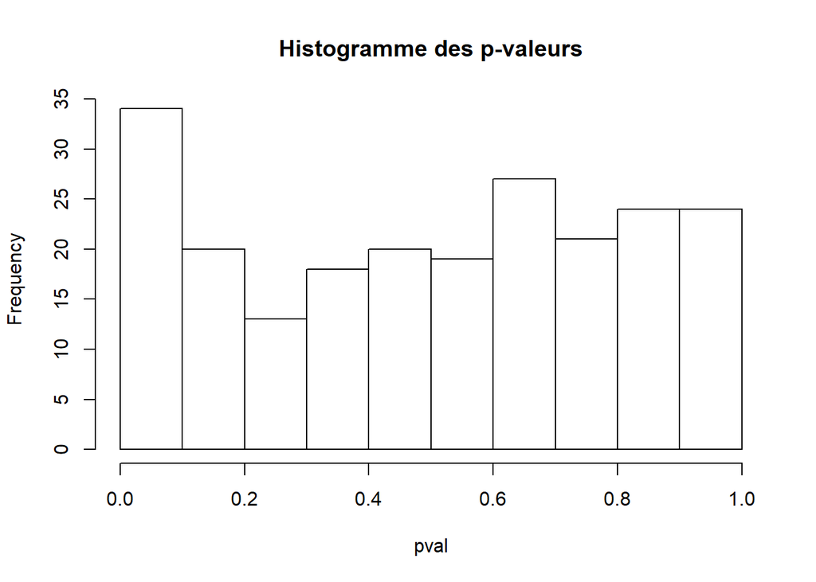

```r
pval = suppressWarnings(apply(snps, 2, function(x) chisq.test(table(x,Y))$p.value))
hist(pval, main="Histogramme des p-valeurs")
```

### Affichons le manhattan plot montrant l’intensité d’association de chaque SNP avec Y

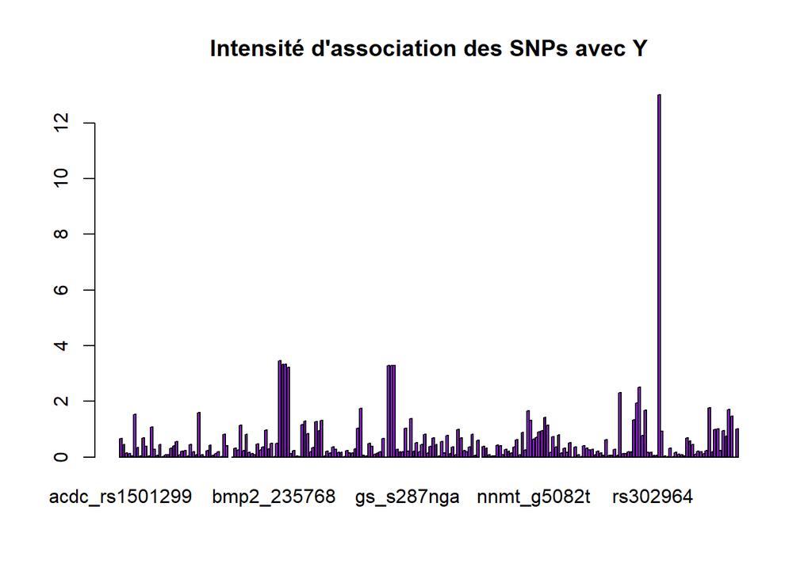

```r
barplot(-log10(pval),col="purple", main="Intensité d'association des SNPs avec Y")
```

```r
datasnp=data.frame(SNP=colnames(snps),CHR=rep(1,ncol(snps)),BP=1:ncol(snps),P=pval,row.names = 1:ncol(snps))
```

### Pour que la probabilité de faire au moins un faux positif sur la totalité des tests soit inférieure à 0.05 il faut faire chaque test au seuil de:

```r
alpha=0.05
(seuil=alpha/length(snps))
```

```
## [1] 0.0002252252
```

### Affichons une barre horizontale à ce niveau sur le Manhattan plot

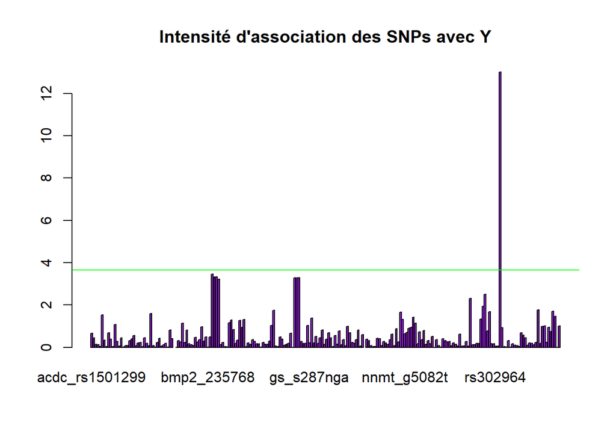

```r
barplot(-log10(pval), col="purple",main="Intensité d'association des SNPs avec Y")
abline(h =-log10(seuil), col = "green")
```

### Correction avec tests multiples

```r
Bonfpv = p.adjust(pval,method="bonferroni")
sum(Bonfpv<=0.05,na.rm = T)
```

```
## [1] 1
```

### Après correction pour les tests multiples,le seul SNP qui semble avoir une association significative avec Y est

```r
which(Bonfpv<=0.05)
```

```
## rs849409
##      194
```

### Faisons un test pour voir si on peut conclure sur l’association entre Y et ce SNP

```r
chisq.test(table(fms$rs849409,Y))
```

[output not shown]

### Au vu de la p-valeur, on peut conclure qu’il y a une association significative entre ce SNP et Y.

#### Chargement du jeu de données

```r
exo5 <- read.table("C:/Users/james/OneDrive/Desktop/DocParisDescartes/S2/StatGen2/exo5.txt", quote="\"", comment.char="")
```

#### Description

##### M: Phénotype, 1 pour les cas et 0 pour les témoins

##### E: Covariable d’exposition environnementale, 1 pour les exposés, 0 pour les non exposés.

##### SNP1-SNP100: génotype 0,1,2 pour 100 SNPs bialléliques, la valeur du génotype indique le nombre d’allèles rares.

### Testons l’association entre tous les SNPs et M

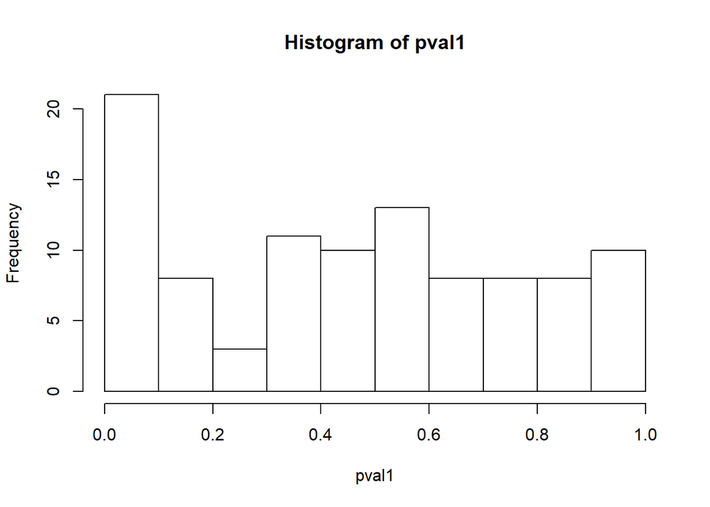

```r
pval1 = suppressWarnings(apply(exo5[,-c(1,2)], 2, function(x) chisq.test(table(x,exo5$M))$p.value))
hist(pval1)
```

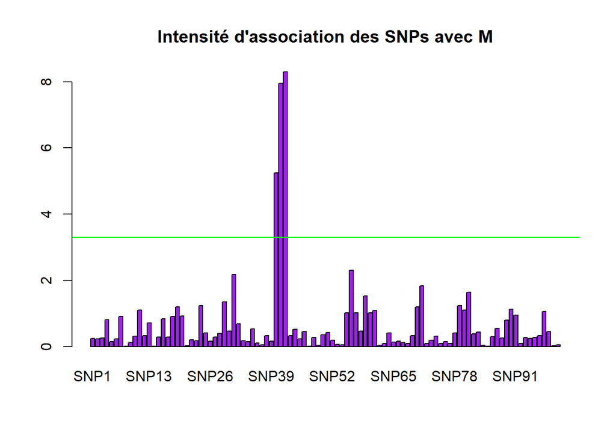

```r
seuil2=alpha/(ncol(exo5)-2)
barplot(-log10(pval1),col="purple",main="Intensité d'association des SNPs avec M")
abline(h = -log10(seuil2), col = "green")
```

```r
sum(pval1<=0.05)
```

```
## [1] 9
```

### Correction avec tests multiples

```r
Bonfpv1 = p.adjust(pval1,method="bonferroni")
sum(Bonfpv1<=0.05,na.rm = T)
```

```
## [1] 3
```

### Les SNPs associés à la maladie sont:

```r
which(Bonfpv1<=0.05)
```

```
## SNP40 SNP41 SNP42
##    40    41    42
```

### 3. Considérons le SNP 42, celui pour lequel le signal d’association est plus forte (c’est à dire pour lequel le test d’association a donné la plus petite p-valeur). Écrivons l’équation du modèle de régression logistique de M sur X

```r
model<-glm(exo5$M~exo5$SNP42, family=binomial(link='logit'),na.action=na.exclude); summary(model)
```

```
##
## Call:
## glm(formula = exo5$M ~ exo5$SNP42, family = binomial(link = "logit"),
##     na.action = na.exclude)
##
## Deviance Residuals:
##    Min      1Q  Median      3Q     Max
## -1.506  -1.045  -1.045   1.089   1.316
##
## Coefficients:
##             Estimate Std. Error z value Pr(>|z|)
## (Intercept) -0.32044    0.07918  -4.047 5.19e-05 ***
## exo5$SNP42   0.53265    0.08981   5.931 3.01e-09 ***
## ---
## Signif. codes:  0 '***' 0.001 '**' 0.01 '*' 0.05 '.' 0.1 ' ' 1
##
## (Dispersion parameter for binomial family taken to be 1)
##
##     Null deviance: 1651.1  on 1190  degrees of freedom
## Residual deviance: 1614.6  on 1189  degrees of freedom
## AIC: 1618.6
##
## Number of Fisher Scoring iterations: 4
```

#### Les coefficients sont significatifs, de plus, $\hat{\beta_{1}}>0$, une augmentation du nombre d’allèles rare de 1 augmente les chances pour que le phénotype M soit égal à 1 de $\exp(0.53265)$

```r
new_model <- lm(exo5$M ~ exo5$SNP42 + exo5$E, na.action=na.exclude); summary(new_model)
```

```
##
## Call:
## lm(formula = exo5$M ~ exo5$SNP42 + exo5$E, na.action = na.exclude)
##
## Residuals:
##     Min      1Q  Median      3Q     Max
## -0.7716 -0.5061 -0.3949  0.4724  0.6051
##
## Coefficients:
##             Estimate Std. Error t value Pr(>|t|)
## (Intercept)  0.39491    0.02079  18.996  < 2e-16 ***
## exo5$SNP42   0.13273    0.02127   6.239 6.11e-10 ***
## exo5$E       0.11124    0.03427   3.246   0.0012 **
## ---
## Signif. codes:  0 '***' 0.001 '**' 0.01 '*' 0.05 '.' 0.1 ' ' 1
##
## Residual standard error: 0.4908 on 1188 degrees of freedom
## Multiple R-squared:  0.03878,    Adjusted R-squared:  0.03716
## F-statistic: 23.96 on 2 and 1188 DF,  p-value: 6.264e-11
```